# MVA_Final_Rutwik_Guntoorkar

Rutwik Guntoorkar

2023-05-01

## Loading the Dataset

```r
library(readxl)
library(MVA)
```

```r
library(HSAUR2)
library(SciViews)
library(scatterplot3d)
library(car)
library(lattice)
library(GGally)
library(ggplot2)
library(ggridges)
library(ggvis)
library(ggthemes)
library(cowplot)
library(gapminder)
library(gganimate)
library(dplyr)
library(tidyverse)
library(grid)
library(gridExtra)
library(RColorBrewer)
library(Hotelling)
library(stats)
library(biotools)
library(factoextra)
library(FactoMineR)
library(ggfortify)
library(psych)
library(corrplot)
library(devtools)
library(cluster)
library(magrittr)
library(NbClust)
library(MASS)
library(gvlma)
library(leaps)
library(relaimpo)
library(e1071)
library(pROC)
library(memisc)
library(ROCR)
library(klaR)
library(caret)
library(caTools)
library(ISLR)
mydata <- read_excel("/Users/rutwik/Desktop/RBS/Sem 2/Multivariate Analysis/Final_MVA_2023.xlsx")


attach(mydata)
```

### Tasks:

> 1. The age of abalone is determined by cutting the shell through the cone, staining it, and counting the number of rings through a microscope – a boring and time-consuming task. You will build a regression model to determine the age of the Abalone from the other attributes. How good is your model? Make sure your residual analysis shows no patterns and is normally distributed. What attributes proved valuable in predicting the age?
> 2. Once you have the model, use the rings column to determine the accuracy measure of your model. Remember, just pick one measure of accuracy (MAPE would be my recommendation)
> 3. Are you able to predict the gender from the other attributres? What is the accuracy using logistic regression? What is the accuracy using LDA? What about the other measures of accuracy?
> 4. Does dimension reduction techniques make your classification model better?

### Analysing the Data

```r
str(mydata)
```

```
## tibble [2,835 × 9] (S3: tbl_df/tbl/data.frame)
##  $ Gender        : chr [1:2835] "M" "M" "F" "M" ...
##  $ Length        : num [1:2835] 0.455 0.35 0.53 0.44 0.53 0.545 0.475 0.55 0.525 0.43 ...
##  $ Diameter      : num [1:2835] 0.365 0.265 0.42 0.365 0.415 0.425 0.37 0.44 0.38 0.35 ...
##  $ Height        : num [1:2835] 0.095 0.09 0.135 0.125 0.15 0.125 0.125 0.15 0.14 0.11 ...
##  $ Whole Weight  : num [1:2835] 0.514 0.226 0.677 0.516 0.777 ...
##  $ Shucked Weight: num [1:2835] 0.2245 0.0995 0.2565 0.2155 0.237 ...
##  $ Viscera weight: num [1:2835] 0.101 0.0485 0.1415 0.114 0.1415 ...
##  $ Shell weight  : num [1:2835] 0.15 0.07 0.21 0.155 0.33 0.26 0.165 0.32 0.21 0.135 ...
##  $ Rings         : num [1:2835] 15 7 9 10 20 16 9 19 14 10 ...
```

```r
mydata$age <- mydata$Rings + 1.5

summary(mydata)
```

```
##     Gender              Length          Diameter          Height
##  Length:2835        Min.   :0.1550   Min.   :0.1100   Min.   :0.0150
##  Class :character   1st Qu.:0.5150   1st Qu.:0.4000   1st Qu.:0.1350
##  Mode  :character   Median :0.5850   Median :0.4600   Median :0.1550
##                     Mean   :0.5696   Mean   :0.4464   Mean   :0.1544
##                     3rd Qu.:0.6350   3rd Qu.:0.5000   3rd Qu.:0.1750
##                     Max.   :0.8150   Max.   :0.6500   Max.   :1.1300
##   Whole Weight    Shucked Weight   Viscera weight    Shell weight
##  Min.   :0.0155   Min.   :0.0065   Min.   :0.0030   Min.   :0.0050
##  1st Qu.:0.7013   1st Qu.:0.2870   1st Qu.:0.1520   1st Qu.:0.2025
##  Median :1.0030   Median :0.4315   Median :0.2170   Median :0.2850
##  Mean   :1.0168   Mean   :0.4391   Mean   :0.2225   Mean   :0.2912
##  3rd Qu.:1.2895   3rd Qu.:0.5687   3rd Qu.:0.2875   3rd Qu.:0.3650
##  Max.   :2.8255   Max.   :1.4880   Max.   :0.7600   Max.   :1.0050
##      Rings           age
##  Min.   : 3.0   Min.   : 4.5
##  1st Qu.: 9.0   1st Qu.:10.5
##  Median :10.0   Median :11.5
##  Mean   :10.9   Mean   :12.4
##  3rd Qu.:12.0   3rd Qu.:13.5
##  Max.   :29.0   Max.   :30.5
```

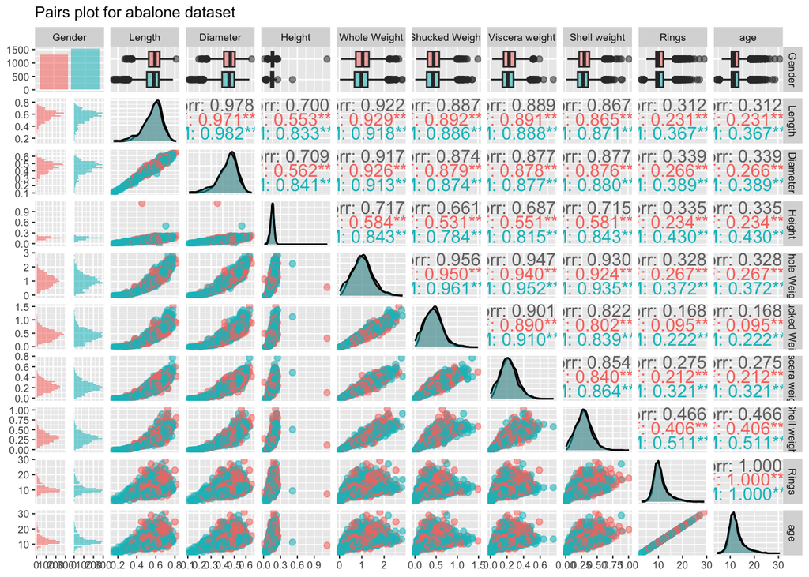

```r
ggpairs(mydata, aes(colour = Gender, alpha = 0.8), title="Pairs plot for abalone dataset") +
  theme_grey(base_size = 8)
```

```r
# Split the data into training and test sets

set.seed(123)
trainIndex <- createDataPartition(mydata$Rings, p = .8,
                                  list = FALSE,
                                  times = 1)
train_data <- mydata[trainIndex, ]
test_data <- mydata[-trainIndex, ]


# Fit a linear regression model to predict age using all other attributes
model <- lm(age ~ .-Rings, data = train_data)

# Evaluate the model on the test set
predictions <- predict(model, newdata = test_data)
library(Metrics)
```

```r
rmse <- rmse(predictions, test_data$age)
mape <- mean(abs((test_data$age - predictions)/test_data$age)) * 100



cat("RMSE:",rmse)
```

```
## RMSE: 2.291639
```

```r
cat("MAPE:",mape)
```

```
## MAPE: 14.3003
```

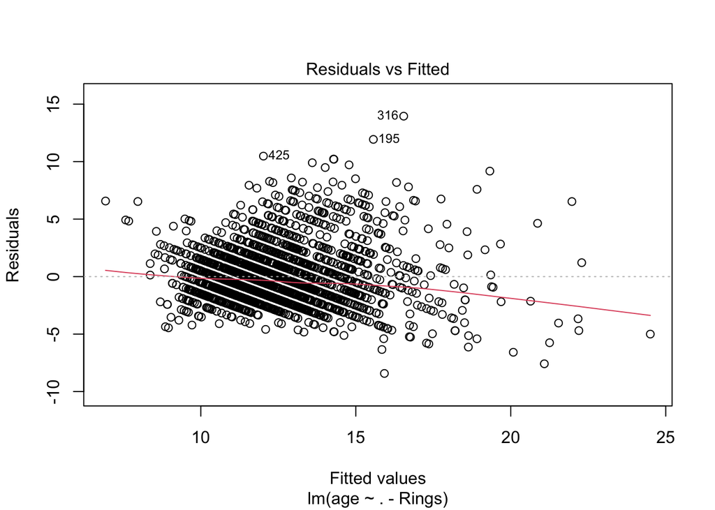

```r
# Check the residuals for patterns and normality
plot(model, which = 1)  # Residuals vs. Fitted plot
```

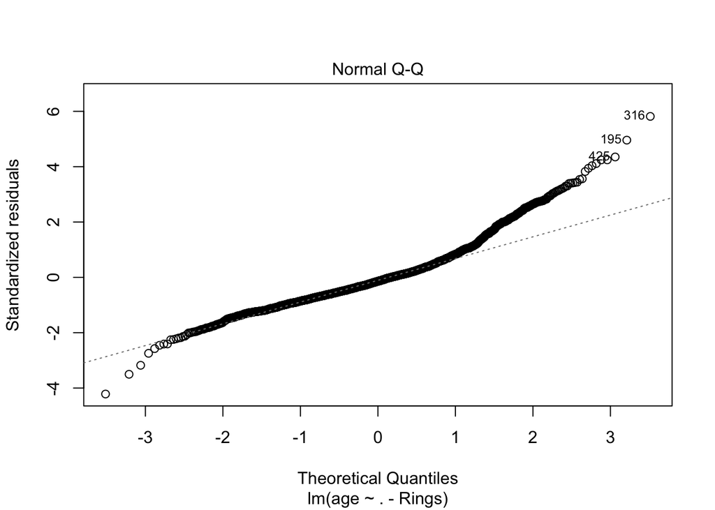

```r
plot(model, which = 2)  # Normal Q-Q plot
```

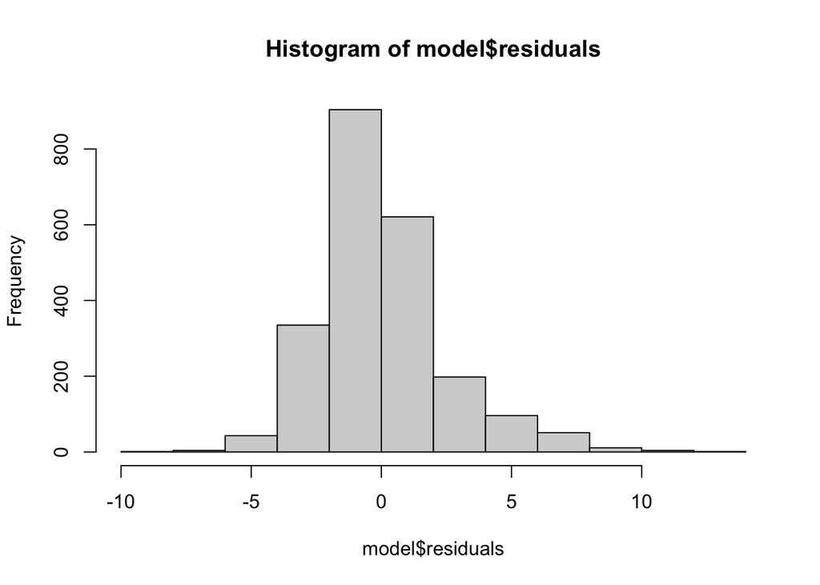

```r
hist(model$residuals)   # Histogram for Residuals
```

```r
# Determine which attributes are valuable in predicting age
summary(model)
```

```
##
## Call:
## lm(formula = age ~ . - Rings, data = train_data)
##
## Residuals:
##     Min      1Q  Median      3Q     Max
## -8.4231 -1.5343 -0.3396  1.0193 13.9546
##
## Coefficients:
##                   Estimate Std. Error t value Pr(>|t|)
## (Intercept)        8.04870    0.56673  14.202  < 2e-16 ***
## GenderM           -0.03153    0.10291  -0.306 0.759372
## Length            -4.23017    2.68044  -1.578 0.114668
## Diameter           9.59755    3.16881   3.029 0.002483 **
## Height             6.30711    1.86644   3.379 0.000739 ***
## `Whole Weight`    10.28429    0.96566  10.650  < 2e-16 ***
## `Shucked Weight` -20.55490    1.10168 -18.658  < 2e-16 ***
## `Viscera weight` -10.33361    1.66908  -6.191 7.07e-10 ***
## `Shell weight`     8.23439    1.51571   5.433 6.15e-08 ***
## ---
## Signif. codes:  0 '***' 0.001 '**' 0.01 '*' 0.05 '.' 0.1 ' ' 1
##
## Residual standard error: 2.411 on 2260 degrees of freedom
## Multiple R-squared:  0.3877, Adjusted R-squared:  0.3855
## F-statistic: 178.8 on 8 and 2260 DF,  p-value: < 2.2e-16
```

```r
# Convert gender column to binary
mydata$Gender <- ifelse(mydata$Gender == "M", 1, 0)

# Split the data into training and testing sets
set.seed(123)
train_size <- floor(0.7 * nrow(mydata))
train_data <- mydata[1:train_size, ]
test_data <- mydata[-(1:train_size), ]

# Build a logistic regression model
log_model <- glm(Gender ~ . - Gender, data = train_data, family = binomial)

# Check the model summary
summary(log_model)
```

```
##
## Call:
## glm(formula = Gender ~ . - Gender, family = binomial, data = train_data)
##
## Deviance Residuals:
##     Min       1Q   Median       3Q      Max
## -1.8208  -1.2001   0.8703   1.1206   1.4855
##
## Coefficients: (1 not defined because of singularities)
##                   Estimate Std. Error z value Pr(>|z|)
## (Intercept)       2.892565   0.534934   5.407  6.4e-08 ***
## Length           -2.398838   2.463329  -0.974   0.3301
## Diameter         -4.111425   2.955083  -1.391   0.1641
## Height           -3.640537   2.295794  -1.586   0.1128
## `Whole Weight`   -0.296612   0.919099  -0.323   0.7469
## `Shucked Weight`  3.307554   1.094019   3.023   0.0025 **
## `Viscera weight` -2.090290   1.547785  -1.351   0.1769
## `Shell weight`    1.245523   1.379184   0.903   0.3665
## Rings            -0.002157   0.018707  -0.115   0.9082
## age                     NA         NA      NA       NA
## ---
## Signif. codes:  0 '***' 0.001 '**' 0.01 '*' 0.05 '.' 0.1 ' ' 1
##
## (Dispersion parameter for binomial family taken to be 1)
##
##     Null deviance: 2738.1  on 1983  degrees of freedom
## Residual deviance: 2683.5  on 1975  degrees of freedom
## AIC: 2701.5
##
## Number of Fisher Scoring iterations: 4
```

```r
# Make predictions on the test set
log_pred <- predict(log_model, newdata = test_data, type = "response")
log_pred <- ifelse(log_pred > 0.5, 1, 0)


# Calculate accuracy measures
table(log_pred, test_data$Gender)
```

```
##
## log_pred   0   1
##        0 156 136
##        1 237 322
```

```r
acc <- sum(log_pred == test_data$Gender)/length(test_data$Gender)
acc
```

```
## [1] 0.5616921
```

```r
# Build an LDA model
lda_model <- lda(Gender ~ . - Gender, data = train_data)
# Check the model summary
summary(lda_model)
```

```
##         Length Class  Mode
## prior    2     -none- numeric
## counts   2     -none- numeric
## means   18     -none- numeric
## scaling  9     -none- numeric
## lev      2     -none- character
## svd      1     -none- numeric
## N        1     -none- numeric
## call     3     -none- call
## terms    3     terms  call
## xlevels  0     -none- list
```

```r
# Make predictions on the test set
lda_pred <- predict(lda_model, newdata = test_data)
lda_pred <- lda_pred$class

# Calculate accuracy measures
table(lda_pred, test_data$Gender)
```

```
##
## lda_pred   0   1
##        0 155 137
##        1 238 321
```

```r
acc <- sum(lda_pred == test_data$Gender)/length(test_data$Gender)
acc
```

```
## [1] 0.559342
```

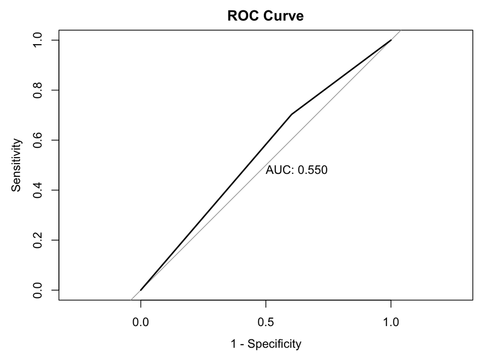

```r
#Plotting AUC plot for logistics regression.
roc <- roc(test_data$Gender, log_pred)
plot(roc, main = "ROC Curve", print.auc = TRUE, legacy.axes = TRUE)
```

### Doing PCA to reduce dimensions in data set.

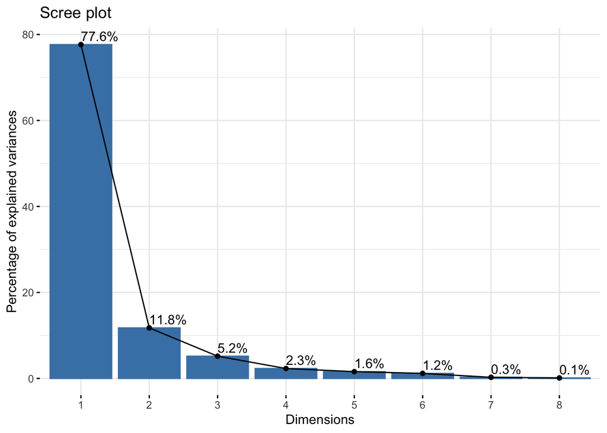

```r
mydata_pca <- prcomp(mydata[2:9],scale. = TRUE)

### Scree diagram
fviz_eig(mydata_pca, addlabels = TRUE)
```

```r
mydata_pca
```

```
## Standard deviations (1, .., p=8):
## [1] 2.49229235 0.96965986 0.64311307 0.42964558 0.35503062 0.30635456 0.14437396
## [8] 0.09646308
##
## Rotation (n x k) = (8 x 8):
##                      PC1         PC2        PC3         PC4          PC5
## Length         0.3844273  0.08368155 -0.1236117  0.55753220  0.087139441
## Diameter       0.3843937  0.04762919 -0.1081034  0.59369982  0.002992088
## Height         0.3170161 -0.09764475  0.9410023 -0.01479292  0.060441223
## Whole Weight   0.3935604  0.08169329 -0.1321286 -0.29155096 -0.049657538
## Shucked Weight 0.3722244  0.25759922 -0.1365502 -0.28952775  0.301817247
## Viscera weight 0.3781237  0.12965991 -0.1234145 -0.35900473  0.351660868
## Shell weight   0.3772628 -0.12735423 -0.0871675 -0.19107786 -0.843784671
## Rings          0.1587843 -0.93548512 -0.1691602 -0.04728752  0.244022877
##                        PC6          PC7          PC8
## Length         -0.04262984  0.713866016  0.008703945
## Diameter       -0.02206736 -0.696638334 -0.002499195
## Height          0.02259033  0.009147931  0.003866025
## Whole Weight    0.13644620 -0.012789304  0.845416731
## Shucked Weight  0.65907316 -0.020672966 -0.408314745
## Viscera weight -0.73001632 -0.043967429 -0.193837391
## Shell weight   -0.05275455  0.049206236 -0.283139380
## Rings           0.09210615  0.007831517 -0.026680054
```

```r
summary(mydata_pca)
```

```
## Importance of components:
##                           PC1    PC2    PC3     PC4     PC5     PC6     PC7
## Standard deviation     2.4923 0.9697 0.6431 0.42965 0.35503 0.30635 0.14437
## Proportion of Variance 0.7764 0.1175 0.0517 0.02307 0.01576 0.01173 0.00261
## Cumulative Proportion  0.7764 0.8940 0.9457 0.96874 0.98450 0.99623 0.99884
##                            PC8
## Standard deviation     0.09646
## Proportion of Variance 0.00116
## Cumulative Proportion  1.00000
```

```r
mydata_pca <- as.data.frame(mydata_pca$x)
mydata_pca <- mydata_pca[1:2]

mydata_pca$Gender <- mydata$Gender

# Split the data into training and testing sets
set.seed(123)
train_size_1 <- floor(0.7 * nrow(mydata_pca))
train_data_1 <- mydata_pca[1:train_size_1, ]
test_data_1 <- mydata_pca[-(1:train_size_1), ]

# Build a logistic regression model
log_model_1 <- glm(Gender ~ . - Gender, data = train_data_1, family = binomial)

# Check the model summary
summary(log_model_1)
```

```
##
## Call:
## glm(formula = Gender ~ . - Gender, family = binomial, data = train_data_1)
##
## Deviance Residuals:
##     Min       1Q   Median       3Q      Max
## -1.4716  -1.2353   0.9901   1.1095   1.4959
##
## Coefficients:
##             Estimate Std. Error z value Pr(>|z|)
## (Intercept)  0.15618    0.04530   3.448 0.000565 ***
## PC1         -0.06415    0.01794  -3.576 0.000348 ***
## PC2          0.10211    0.04471   2.284 0.022381 *
## ---
## Signif. codes:  0 '***' 0.001 '**' 0.01 '*' 0.05 '.' 0.1 ' ' 1
##
## (Dispersion parameter for binomial family taken to be 1)
##
##     Null deviance: 2738.1  on 1983  degrees of freedom
## Residual deviance: 2719.5  on 1981  degrees of freedom
## AIC: 2725.5
##
## Number of Fisher Scoring iterations: 4
```

```r
# Make predictions on the test set
log_pred_1 <- predict(log_model_1, newdata = test_data_1, type = "response")
log_pred_1 <- ifelse(log_pred_1 > 0.5, 1, 0)


# Calculate accuracy measures
table(log_pred_1, test_data_1$Gender)
```

```
##
## log_pred_1   0   1
##          0  72  76
##          1 321 382
```

```r
acc_1 <- sum(log_pred_1 == test_data_1$Gender)/length(test_data_1$Gender)
acc_1
```

```
## [1] 0.53349
```

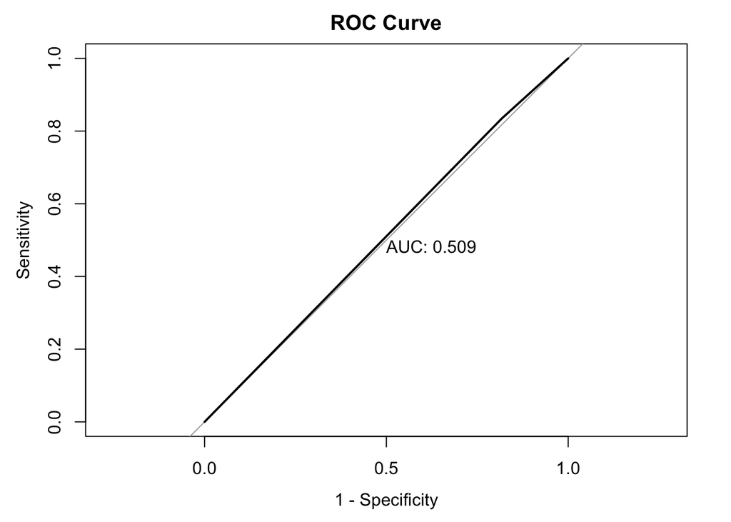

```r
#Plotting AUC plot for logistics regression.
roc1 <- roc(test_data_1$Gender, log_pred_1)
plot(roc1, main = "ROC Curve", print.auc = TRUE, legacy.axes = TRUE)
```

### Observations:

> - After performing logistic regression on PCs, the result was not improved as AUC comes to be 50.9%

### Checking wheter the results are better withv Exploratory Factor Analysis (EFA)

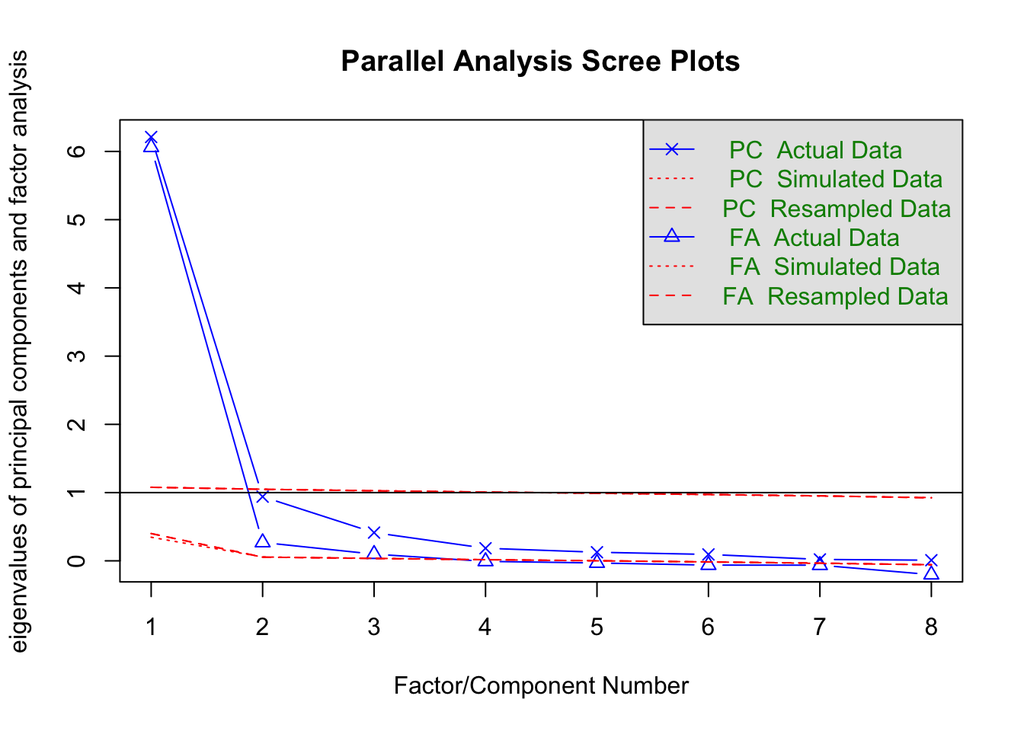

```
## Parallel analysis suggests that the number of factors =  3  and the number of components =  1
```

```r
fa.parallel(mydata[2:9])
```

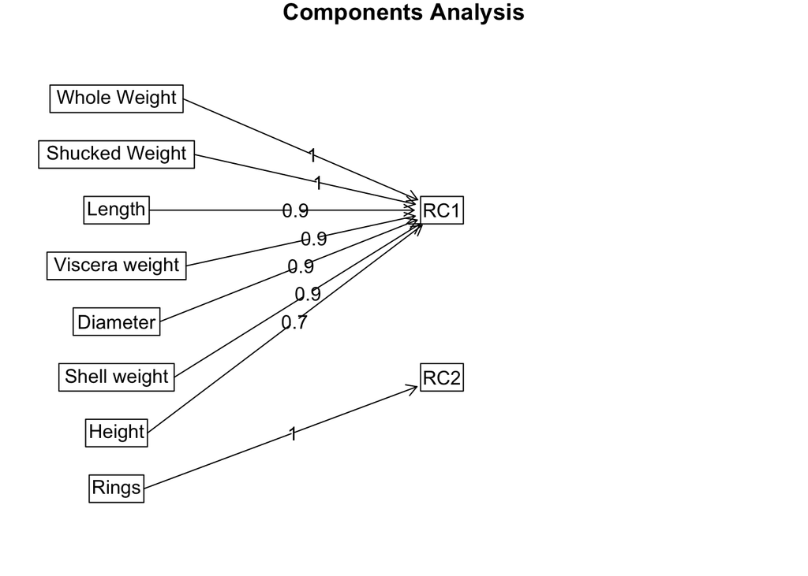

```r
fit.pc <- principal(mydata[2:9], nfactors=2, rotate="varimax")
fa.diagram(fit.pc)
```

```r
efa_mydata <- as.data.frame(fit.pc$scores)
efa_mydata$Gender <- mydata$Gender

# Split the data into training and testing sets
set.seed(123)
train_size_2 <- floor(0.8 * nrow(efa_mydata))
train_data_2 <- efa_mydata[1:train_size_2, ]
test_data_2 <- efa_mydata[-(1:train_size_2), ]

# Build a logistic regression model
log_model_2 <- glm(Gender ~ . - Gender, data = train_data_2, family = binomial)

# Check the model summary
summary(log_model_2)
```

```
##
## Call:
## glm(formula = Gender ~ . - Gender, family = binomial, data = train_data_2)
##
## Deviance Residuals:
##     Min       1Q   Median       3Q      Max
## -1.4671  -1.2331   0.9944   1.1105   1.4796
##
## Coefficients:
##             Estimate Std. Error z value Pr(>|z|)
## (Intercept)  0.15764    0.04235   3.723 0.000197 ***
## RC1         -0.12843    0.04243  -3.027 0.002471 **
## RC2         -0.13052    0.04095  -3.187 0.001435 **
## ---
## Signif. codes:  0 '***' 0.001 '**' 0.01 '*' 0.05 '.' 0.1 ' ' 1
##
## (Dispersion parameter for binomial family taken to be 1)
##
##     Null deviance: 3130.4  on 2267  degrees of freedom
## Residual deviance: 3110.6  on 2265  degrees of freedom
## AIC: 3116.6
##
## Number of Fisher Scoring iterations: 4
```

```r
# Make predictions on the test set
log_pred_2 <- predict(log_model_2, newdata = test_data_2, type = "response")
log_pred_2 <- ifelse(log_pred_2 > 0.5, 1, 0)


# Calculate accuracy measures
table(log_pred_2, test_data_2$Gender)
```

```
##
## log_pred_2   0   1
##          0  39  45
##          1 222 261
```

```r
acc_2 <- sum(log_pred_2 == test_data_2$Gender)/length(test_data_2$Gender)
acc_2
```

```
## [1] 0.5291005
```

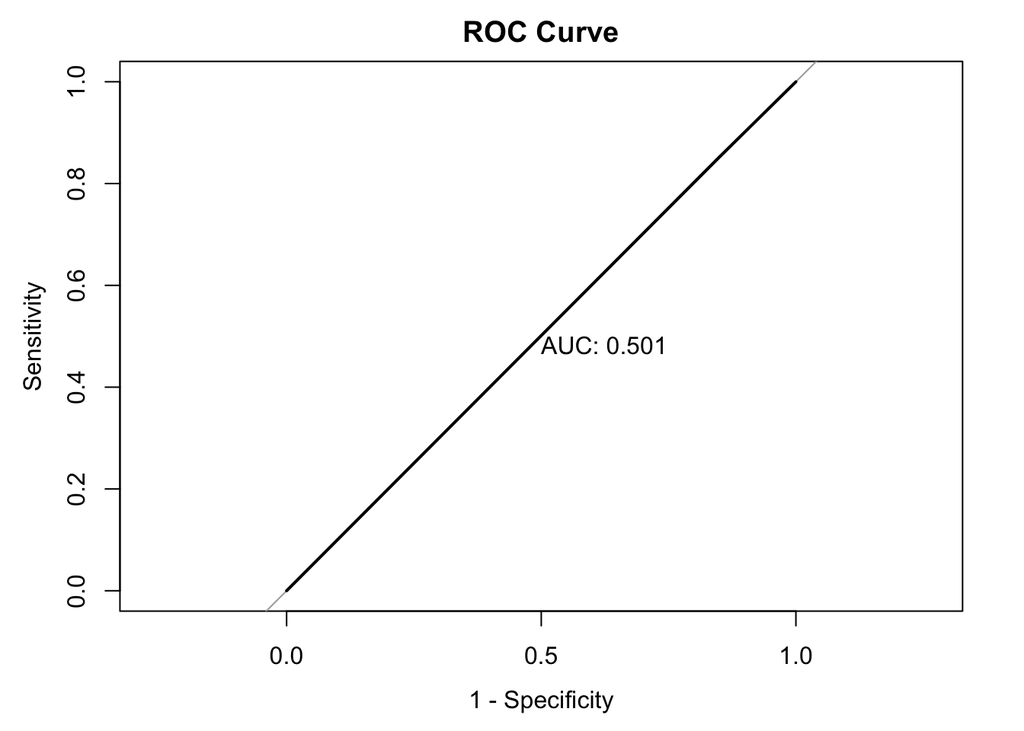

```r
#Plotting AUC plot for logistics regression.
roc2 <- roc(test_data_2$Gender, log_pred_2)
plot(roc2, main = "ROC Curve", print.auc = TRUE, legacy.axes = TRUE)
```

### Observations:

> - Even after performing logistic regression on Factors, the result was not improved as AUC comes to be 50.1% only so we can conclude that in this case, dimension reduction techniques did not make classification model better.